# Final Report

#### Wyoming noticably has the largest per capita accidents in this category, mainly due to their small population and the risks that are posed on these trucking services due to wide open highways and unexpected and severe weather than can occur, such as in the winter season.

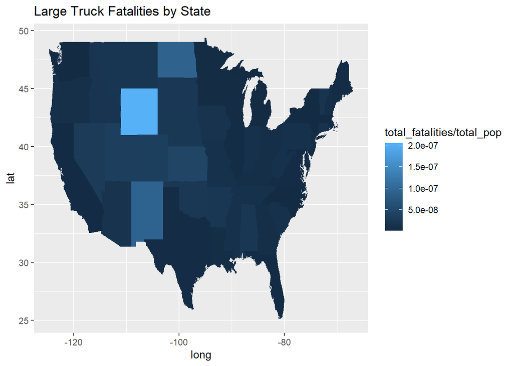

#### Texas has the largest number of fatalites for large trucks, due to their large population, and for how massive the state is.

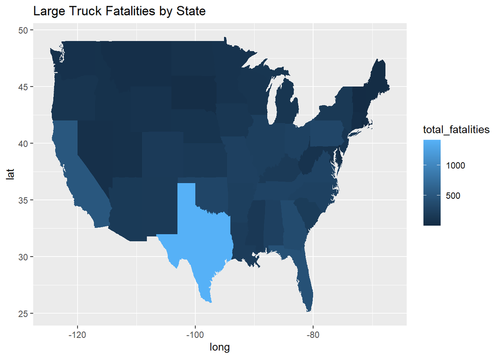

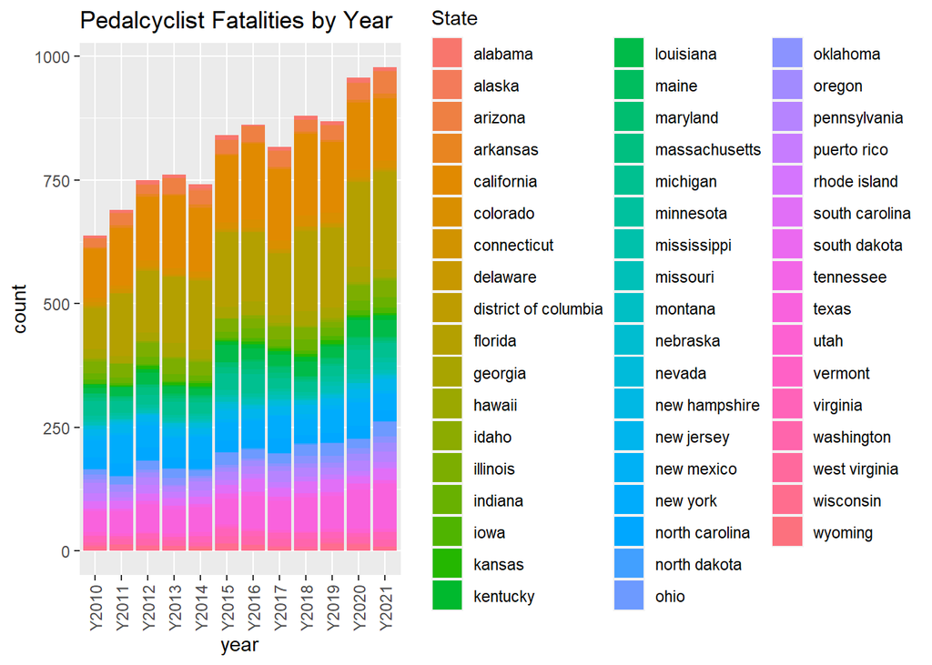

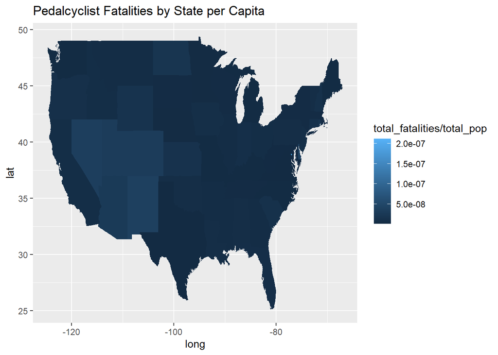

#### It’s interesting to see that the highest number of pedacyclist accidents occur in California and Flordia, this could be due to their nicer climates, where there are more days were cyclists are on the road.

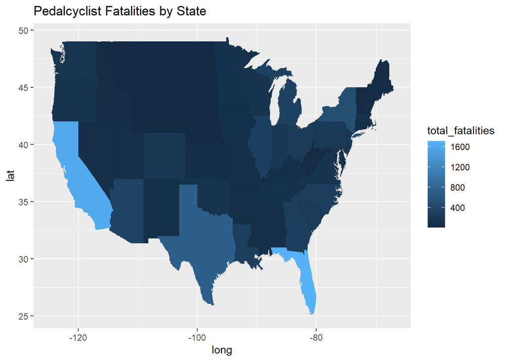

#### With passenger vehicles and SUV’s being some of the most common type of vehicles on the road, it’s not unexpected that their fatality numbers are higher than any other categories in this data. Some of the highest passenger car fatal accidents seem to occur in the Great Plains and Rocky Mountain regions of the United States. This is most likely due to the terrain being more difficult and dangerous to drive on, especially in the winter season. These rates could further be caused by inexperienced drivers and tourists in these areas.

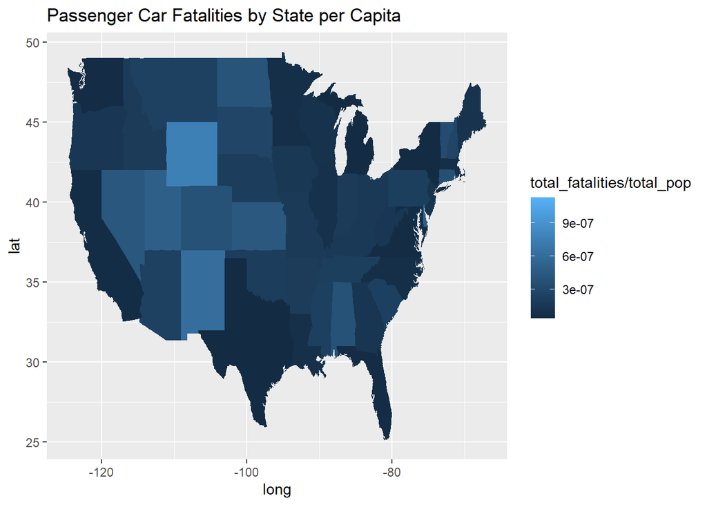

#### Overall, California, Texas, and Flordia have the highest total number of passenger vehicle fatal accidents. There is also a noticable difference between the eastern and western United States, with the eastern states having an average of more passenger car fatalities.

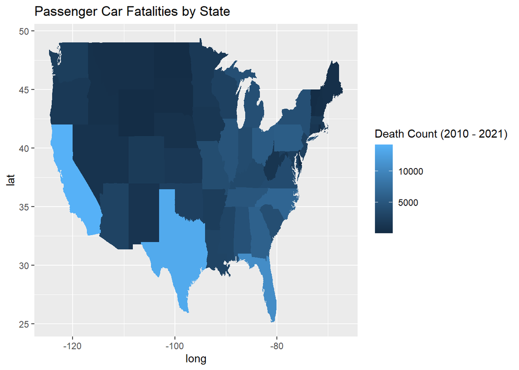

#### This data also appears to be similar to SUV highway fatalites, both per capita and overall.

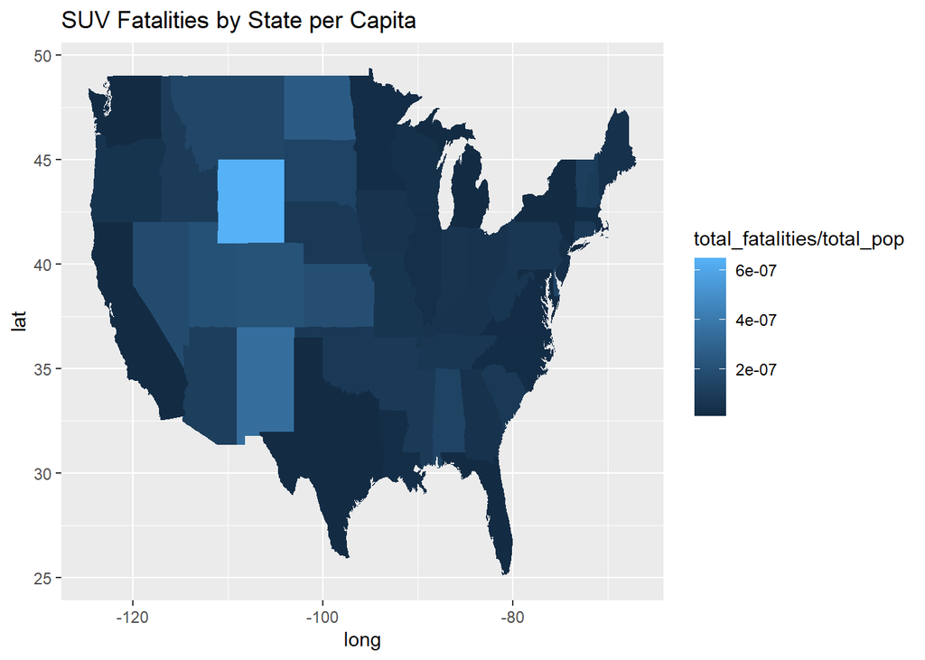

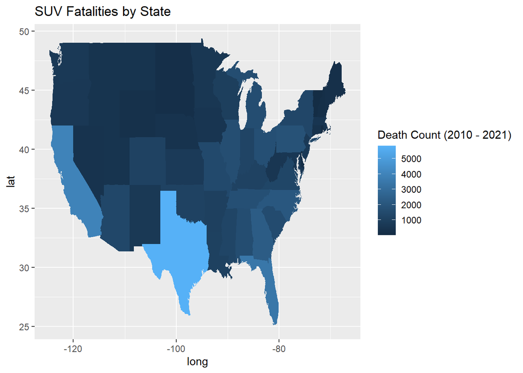

#### Doesn’t seem to be any decrease or increase in passenger car fatalites over the years.

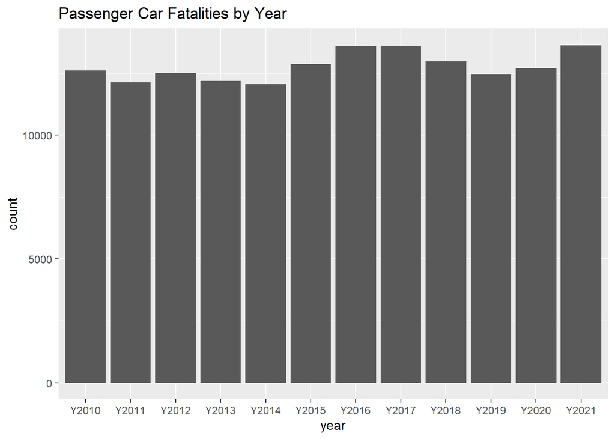

#### However, there is a sharp increase of SUV fatalites in the later years. This could be caused by more people buying and driving SUVs in the United States, as some of the most popular vehicles on the road these days seems to be these larger vehicles.

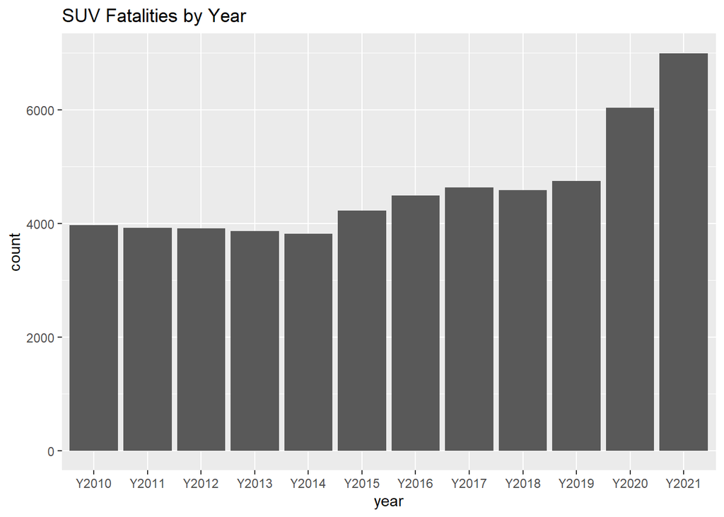

#### Here, this plot shows the total number of nonoccupant fatalites by state, this being non-traffic fatalites that occured on American highways. This data spikes in states such as California, Arizona, Texas, and Flordia.

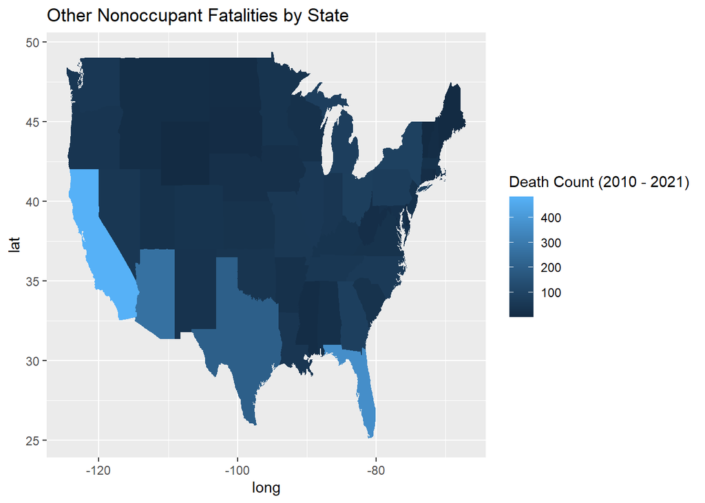

### Investigating Correlations to State Revenue & Expenditure

#### Reading and Formatting the Financial Data

```
##                 RevenueType    Alabama    Alaska    Arizona   Arkansas
## 1             Total revenue 34,406,665 9,871,576 45,234,078 23,867,218
## 2           General revenue 30,779,818 8,699,894 40,422,551 22,133,182
## 3 Intergovernmental revenue 11,406,585 3,703,979 16,861,452  7,896,933
## 4                     Taxes 11,782,220 1,780,911 18,163,903 10,217,866
## 5             General sales  3,116,142            8,358,260  3,573,456
## 6           Selective sales  2,713,061   278,823  2,085,528  1,347,012
##    California   Colorado Connecticut   Delaware     Florida    Georgia
## 1 398,531,883 37,530,888  37,368,326 10,127,416 102,606,004 54,843,065
## 2 331,185,972 31,988,226  32,147,127  9,478,368  92,856,198 47,366,852
## 3 102,470,586  9,087,124   8,786,640  2,564,999  29,283,126 15,788,655
## 4 187,638,267 15,869,834  19,131,944  4,596,190  45,017,095 24,723,046
## 5  41,539,499  3,375,058   4,589,035             28,006,498  6,250,310
## 6  18,093,378  2,613,477   3,198,853    602,601   8,485,578  3,259,155
##       Hawaii      Idaho   Illinois    Indiana       Iowa     Kansas   Kentucky
```

[output cut: 48 more lines]

```
## # A tibble: 6 × 3
##   RevenueType   State      `Amount (Per 1000)`
##   <chr>         <chr>                    <dbl>
## 1 Total revenue alabama               34406665
## 2 Total revenue alaska                 9871576
## 3 Total revenue arizona               45234078
## 4 Total revenue arkansas              23867218
## 5 Total revenue california           398531883
## 6 Total revenue colorado              37530888
```

#### Joining Financial Data with Traffic Fatality Data

```
##        long      lat group order   State subregion                 FatalityType
## 1 -87.46201 30.38968     1     1 alabama      <NA>           Highway Fatalities
## 2 -87.46201 30.38968     1     1 alabama      <NA>     Passenger Car Fatalities
## 3 -87.46201 30.38968     1     1 alabama      <NA>               SUV Fatalities
## 4 -87.46201 30.38968     1     1 alabama      <NA>      Pickup Truck Fatalities
## 5 -87.46201 30.38968     1     1 alabama      <NA>               Van Fatalities
## 6 -87.46201 30.38968     1     1 alabama      <NA> Other Light Truck Fatalities
##   TotalFatalities  year count population
## 1           10976 Y2019   930    4907965
## 2            4507 Y2019   362    4907965
## 3            1632 Y2019   126    4907965
## 4            1806 Y2019   160    4907965
## 5             291 Y2019    21    4907965
## 6              22 Y2019     4    4907965
```

```
##        long      lat group order   State subregion       FatalityType
## 1 -87.46201 30.38968     1     1 alabama      <NA> Highway Fatalities
## 2 -87.46201 30.38968     1     1 alabama      <NA> Highway Fatalities
## 3 -87.46201 30.38968     1     1 alabama      <NA> Highway Fatalities
## 4 -87.46201 30.38968     1     1 alabama      <NA> Highway Fatalities
## 5 -87.46201 30.38968     1     1 alabama      <NA> Highway Fatalities
## 6 -87.46201 30.38968     1     1 alabama      <NA> Highway Fatalities
##   TotalFatalities  year count population               RevenueType
## 1           10976 Y2019   930    4907965             Total revenue
## 2           10976 Y2019   930    4907965           General revenue
## 3           10976 Y2019   930    4907965 Intergovernmental revenue
## 4           10976 Y2019   930    4907965                     Taxes
## 5           10976 Y2019   930    4907965             General sales
## 6           10976 Y2019   930    4907965           Selective sales
##   Amount (Per 1000)
## 1          34406665
## 2          30779818
## 3          11406585
## 4          11782220
## 5           3116142
## 6           2713061
```

#### Investigating Correlations of Traffic Fatalities with Total State Revenue

##### Here, we investigate would state revenue and expenditure have a correlation with traffic fatalities? For this, we observed that there is a correlation between revenue and expenditure in most states.

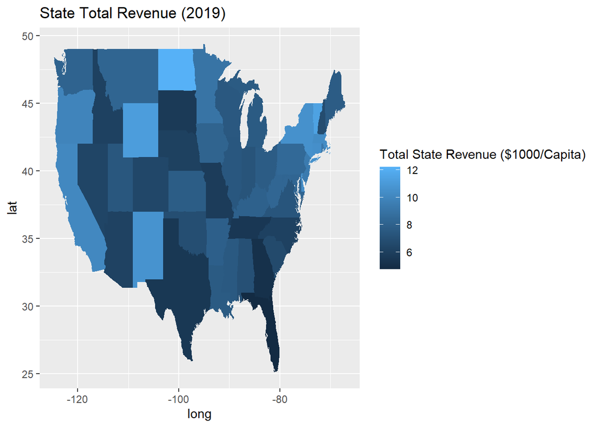

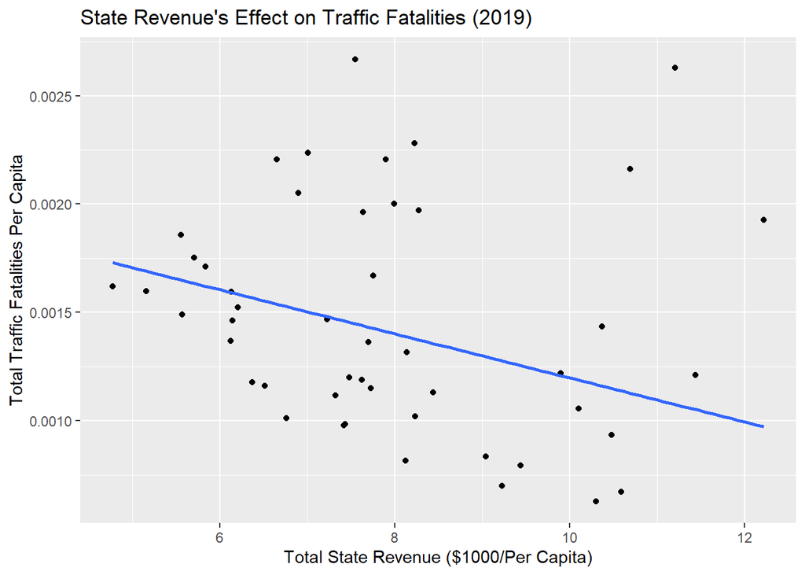

#### Investigating Correlations of Traffic Fatalities with Police Expenditure

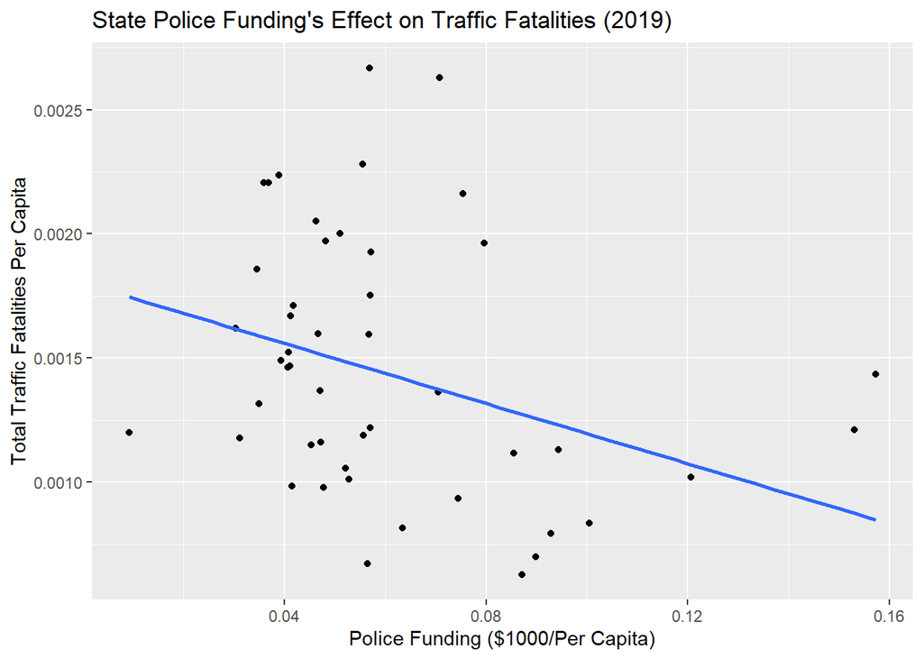

#### Investigating Correlations of Traffic Fatalities with Total State Expenditure

##### Here, we investigated if state revenue and expenditure have a correlation with traffic fatalities? What we found is that we observed a negative correlation between revenue and expenditure and traffic fatalities.

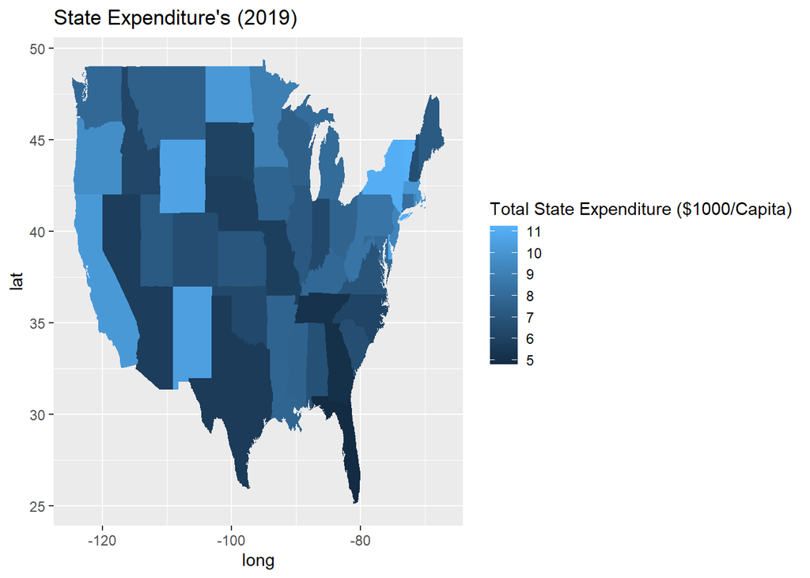

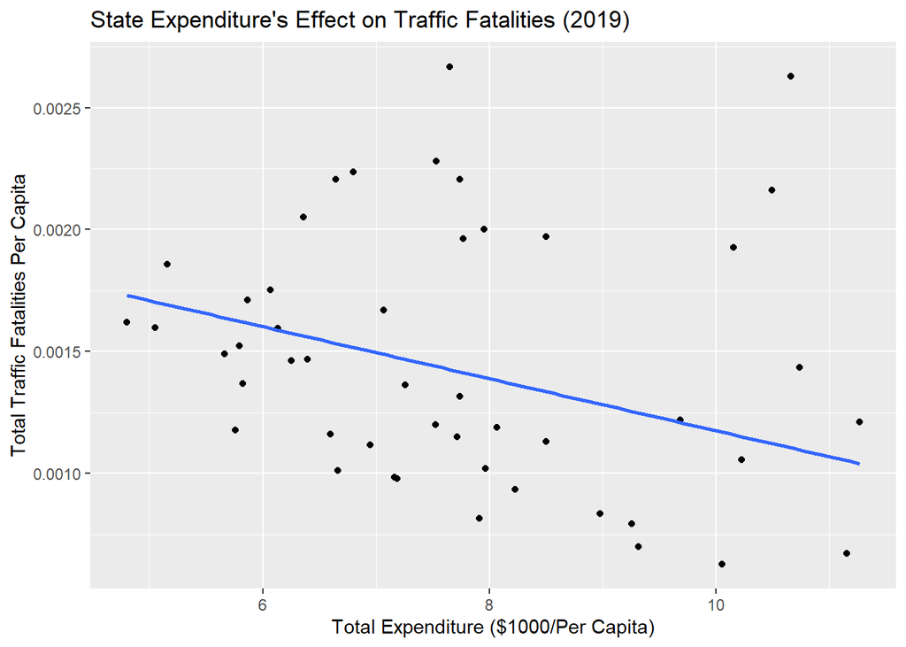

#### Investigating Correlations of Traffic Fatalities with Education Expenditure

##### Here, we looked into what impact would specific types of state funding (expenditure) have on traffic fatalities? From our data, we found that state funding on services like policing and education had a weak negative correlation to traffic fatalities.

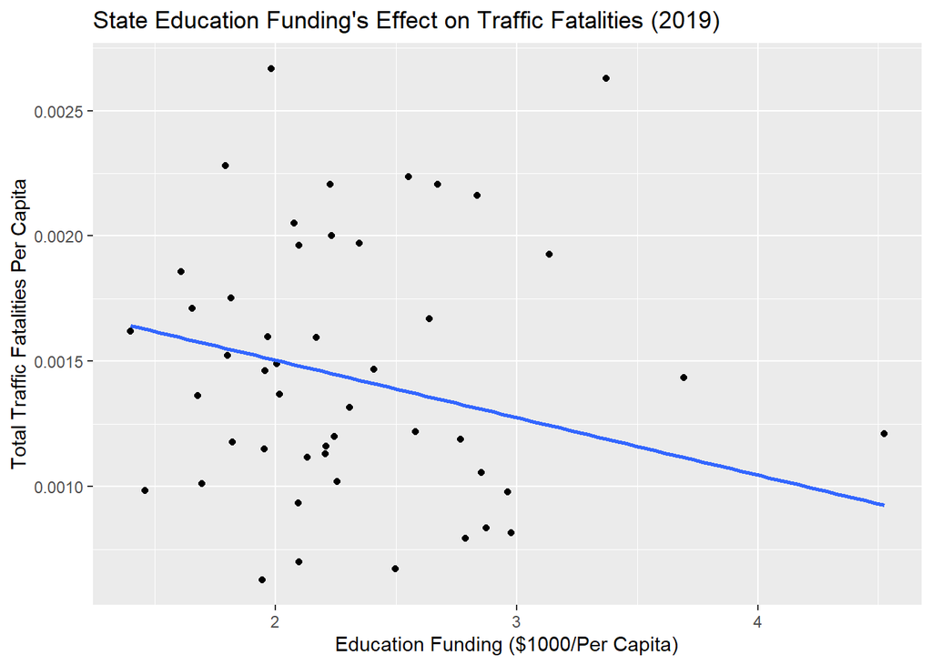

### Results:

#### Analysis of COVID and Fatality Impact 2020-2021

The first cases of COVID-19 reached the US in January 2020, and the Trump Administration declared a nationwide emergency on the COVID-19 pandemic in March 2021. (https://www.cdc.gov/museum/timeline/covid19.html).

However, according to the National Highway Traffic Safety Administration, the number of fatal traffic crashes increased by 6.8%. This would seem strange, considering that less people overall were driving on the road without the need to commute to work. (https://www.nhtsa.gov/press-releases/2020-traffic-crash-data-fatalities)

Megan McArdle, a columnist the Washington Post, indicated that this may be due to an increase in young and risky male drivers taking advantage of empty COVID-era roads. A study done by the AAA Foundation for Traffic Safety indicated that young males were the only people who indicated that they were driving more during the COVID pandemic - taking their risky driving with them. (https://www.washingtonpost.com/opinions/2022/03/10/pandemic-risky-driving-maybe-here-to-stay/).

In addition, according to Michael Wilbur, a PHD Student in Vanderbilt University, in a paper published in the Transportation Research Record: Journal of the Transportation Research Board, bus fatalities is also an exception to the sudden spike of fatal accidents due to a decrease in operation hours for buses during the COVID-19 pandemic, as well as social distancing measures and precautions advised and enforced by state legislature. (https://www.ncbi.nlm.nih.gov/pmc/articles/PMC10107069/)